Skip to main content

# Лабораторна робота №3. Основи регресійного моделювання

Прогноз економності автомобілів (Auto MPG)

Author

Табачук Олександр Ігорович, група КН-42

Published

24.11.2026

**Код**

```python
import json, platform, sys
from pathlib import Path
sys.path.insert(0, str(Path.cwd() / "src"))
import matplotlib, matplotlib.pyplot as plt
import numpy as np, pandas as pd, scipy, sklearn, statsmodels
import statsmodels.formula.api as smf
from IPython.display import Markdown
from scipy import stats
from sklearn.base import clone
from statsmodels.nonparametric.smoothers_lowess import lowess
from statsmodels.stats.diagnostic import het_breuschpagan
from lab3 import SEED, load_data, split, make_models, metrics, cross_validate

FIG, TAB = Path("outputs/figures"), Path("outputs/tables")
for p in (FIG, TAB): p.mkdir(parents=True, exist_ok=True)
plt.rcParams.update({"figure.dpi": 110, "savefig.dpi": 150, "axes.grid": True,
                     "grid.alpha": .3, "axes.spines.top": False, "axes.spines.right": False})
COL = {"США": "#4C72B0", "Європа": "#55A868", "Японія": "#C44E52"}

def save(fig, name):
    fig.tight_layout(); fig.savefig(FIG / f"{name}.png", bbox_inches="tight"); plt.show()

def uk(x, d=2):
    return f"{x:.{d}f}".replace("-", "−").replace(".", ",")

def ci(lo, hi, d=2):
    return f"[{uk(lo, d)}; {uk(hi, d)}]"

def pf(p):
    return "p < 0,001" if p < .001 else f"p = {uk(p, 3)}"

def md(df, d=2):
    return Markdown(df.map(lambda v: uk(v, d) if isinstance(v, float) else v).to_markdown(index=False, disable_numparse=True))
```

# 1 Вступ: питання, література та гіпотези

**Предметна область.** Економність пального легкових автомобілів ринку США 1970–1982 модельних років. **Одиниця спостереження** — модель автомобіля певного модельного року. **Ціль** — `mpg`, пробіг у милях на галон США (неперервна; більше означає економніше; л/100 км = 235,215 / mpg).

**Дослідницьке питання.** Наскільки точно можна спрогнозувати `mpg` моделі, якої немає в навчальних даних, за її масою, потужністю, модельним роком і регіоном виробника, та які зв’язки з `mpg` підтримують дані?

Прогноз потрібен для **інших моделей того самого ринку й періоду**. Роки після 1982 не прогнозуємо.

## 1.1 Література

Зіставлення предметних джерел

| Джерело | Що встановлено | Що взято для цієї роботи |
| --- | --- | --- |
| Knittel (2011) | Оцінює технологічний прогрес і компроміс між економністю, масою та потужністю. За незмінних маси, потужності й крутного моменту на рівні 1980 р. економність до 2006 р. могла зрости майже на 60 % | Маса й потужність входять до моделі разом. Рік — наближення технологічного прогресу, очікуваний знак «+» |
| Reynolds і Kandlikar (2007) | Для звичайних авто на ринку США 2007 р. +100 кг маси пов’язані з +0,7 л/100 км | Очікуваний знак маси для `mpg` — «−». Якщо витрата (л/100 км) зростає з масою приблизно лінійно, то обернена величина `mpg` залежить від маси нелінійно |
| EPA (2026) | З 1975 до початку 1980-х економність швидко зростала, а маса й потужність падали; ці характеристики не є незалежними | Межа інтерпретації: рік, маса й потужність змінювалися одночасно, тому коефіцієнти — умовні асоціації, а не ефекти втручання |

**Синтез.** Джерела узгоджені щодо знаку: важчі й потужніші авто менш економні. Акцент відрізняється: Reynolds і Kandlikar порівнюють авто одного року, тобто бачать зв’язок із конструкцією, а Knittel та EPA розглядають зміни в часі, коли прогрес частково маскується або підсилюється зміною маси й потужності. Тому рік, маса й потужність мають входити в одну модель. Сам набір для прогнозування використав, зокрема, Quinlan (1993).

## 1.2 Гіпотези

Записані до оцінювання моделей. Обидві **підказані також EDA з лабораторної №2** на тому самому наборі, тому їхні результати подано як **розвідувальні**.

- **H1 (маса).** За однакових потужності, року й регіону більша маса пов’язана з меншим `mpg`. *Перевірка:* знак, величина й 95 % ДІ коефіцієнта маси в лінійній моделі M1; очікуємо, що ДІ цілком нижчий за 0.
- **H2 (рік).** За однакових маси, потужності й регіону новіші авто економніші. *Перевірка:* 95 % ДІ коефіцієнта року в M1; очікуємо, що ДІ цілком вищий за 0.

# 2 Методи: дані, EDA та план перевірки

## 2.1 Дані та поділ

**Код**

```python
df = load_data()
train, test = split(df)
assert not set(train.model_id) & set(test.model_id)
```

Auto MPG (R. Quinlan 1993), UCI Machine Learning Repository, ліцензія CC BY 4.0. Файл `auto-mpg.data` отримано для лабораторної №2 в листопаді 2026 р. і збережено в репозиторії без змін. Обсяг: 398 спостережень, 300 унікальних назв моделей, пропущено 6 значень `horsepower`. Обмеження: лише ринок США, без обсягів продажу, типу пального й трансмісії; регіони незбалансовані.

**Поділ.** Деякі моделі повторюються в різні роки (наприклад, *ford pinto*), тому рядки не цілком незалежні. Поділ приблизно 80/20 виконано **за назвою моделі** (описки в назвах марок виправлено), `seed = 42`: навчальна частина — 312 спостережень, тестова — 86. Жодна назва не потрапила в обидві частини.

**Обмеження незалежності тесту.** EDA в лабораторній №2 виконано на *всіх* 398 спостереженнях. Вона вже підказала набір предикторів (маса, потужність, рік, регіон без дубльованих розмірних ознак), логарифмування цілі та перевірку нелінійності. Тому тестова оцінка може бути дещо оптимістичною. Нових даних немає; EDA нижче виконано лише на навчальній частині.

## 2.2 Висновки EDA

З лабораторної №2: `mpg` має правосторонню асиметрію; єдиний викид за IQR (Mazda GLC, 46,6 mpg) реальний і залишений; маса має найсильніший зв’язок із ціллю (ρ ≈ −0,88); маса, об’єм, потужність і циліндри мультиколінеарні (VIF до 20); регіональна різниця переважно пояснюється масою.

**Код**

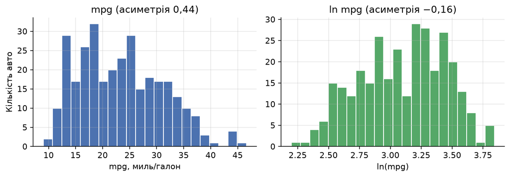

Figure 1: Розподіл цілі на навчальній частині: у вихідній шкалі та після логарифмування

```python
fig, ax = plt.subplots(1, 2, figsize=(9, 3.2))
ax[0].hist(train.mpg, bins=22, color="#4C72B0", edgecolor="white")
ax[0].set(xlabel="mpg, миль/галон", ylabel="Кількість авто", title=f"mpg (асиметрія {uk(stats.skew(train.mpg))})")
ax[1].hist(np.log(train.mpg), bins=22, color="#55A868", edgecolor="white")
ax[1].set(xlabel="ln(mpg)", title=f"ln mpg (асиметрія {uk(stats.skew(np.log(train.mpg)))})")
save(fig, "eda_target")
```

**Рішення:** перевірити модифікацію з ln(mpg), де розподіл симетричніший.

**Код**

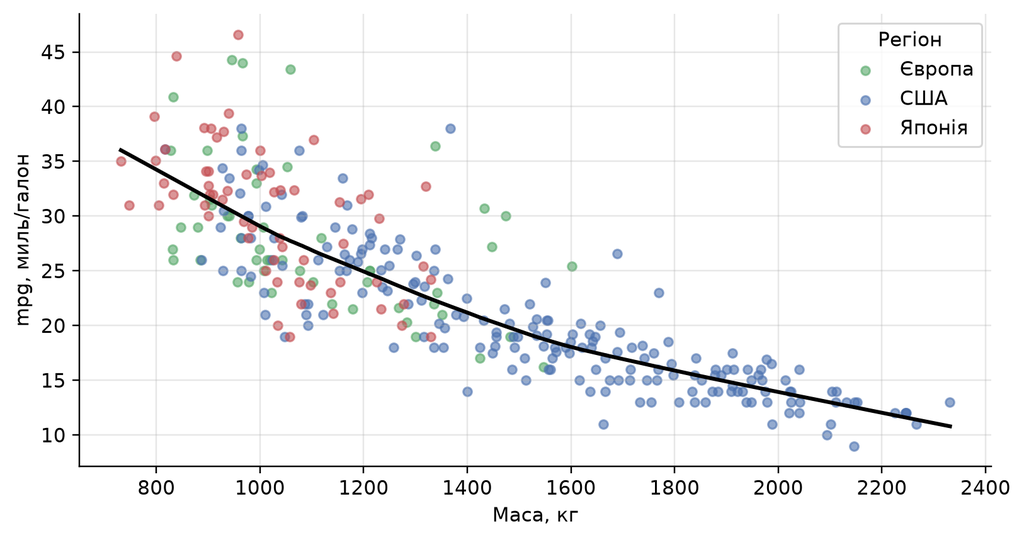

Figure 2: Маса й mpg за регіоном (навчальна частина); чорна лінія — LOWESS

```python
fig, ax = plt.subplots(figsize=(7.5, 4))
for o, g in train.groupby("origin"):
    ax.scatter(g.w100 * 100, g.mpg, s=20, alpha=.6, color=COL[o], label=o)
lw = lowess(train.mpg, train.w100 * 100, frac=.5); ax.plot(*lw.T, "k", lw=2)
ax.set(xlabel="Маса, кг", ylabel="mpg, миль/галон"); ax.legend(title="Регіон")
save(fig, "eda_weight")
```

**Рішення:** маса входить у модель; крива опукла, тож лінійного члена може бракувати. Перевіряємо квадрат маси та логарифмічну форму. Регіон додаємо як категорію.

**Код**

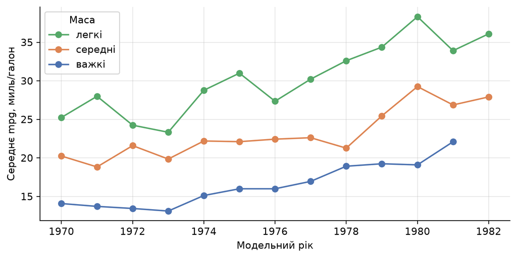

Figure 3: mpg за модельним роком для терцилів маси (навчальна частина, середні)

```python
fig, ax = plt.subplots(figsize=(7.5, 3.8))
wg = pd.qcut(train.w100, 3, labels=["легкі", "середні", "важкі"])
for (n, g), c in zip(train.groupby(wg, observed=True), ["#55A868", "#DD8452", "#4C72B0"]):
    s = g.groupby("model_year").mpg.mean(); ax.plot(1900 + s.index, s, "o-", color=c, label=n)
ax.set(xlabel="Модельний рік", ylabel="Середнє mpg, миль/галон"); ax.legend(title="Маса")
save(fig, "eda_year")
```

**Рішення:** рік потрібен і за подібної маси. Темп зростання в групах може відрізнятися, тому перевіряємо взаємодію маса × рік.

## 2.3 План оцінювання (зафіксовано до відкриття тесту)

- **Валідація:** на навчальній частині, 5-кратна групова CV за назвою моделі, 10 повторів (50 розбиттів, однакових для всіх моделей).
- **Захист від витоку:** медіанна імпутація потужності, масштабування (ridge) і поправка Дуана оцінюються лише на навчальній частині кожного розбиття. Параметр ridge підбирається всередині неї (узагальнена CV, без урахування груп).
- **Доступність предикторів:** маса, потужність, рік, регіон, об’єм, циліндри й розгін є технічними характеристиками, відомими незалежно від вимірювання витрати. Похідна л/100 км до предикторів не входить.
- **Основна метрика — RMSE** у mpg: великі промахи для вибору авто шкідливіші за кілька малих, а середнє (константний орієнтир) мінімізує саме квадратичну похибку. MAE подаємо додатково.
- **Правило вибору:** найменший середній CV-RMSE. Якщо простіша модель поступається менш ніж на 1 %, обираємо простішу.
- **Тест** відкривається один раз для обраної моделі та константи.

# 3 Результати: моделі, діагностика та порівняння

## 3.1 Орієнтир і базова регресія

M0 прогнозує середнє `mpg` навчальної частини: 23,46 mpg.

$$\text{M1: } mpg = \beta_0 + \beta_1\,\frac{\text{маса}}{100\,\text{кг}} + \beta_2\,\frac{\text{к. с.}}{10} + \beta_3(\text{рік}-1976) + \beta_4\,[\text{Європа}] + \beta_5\,[\text{Японія}] + \varepsilon$$

Маса й потужність відображають дві сторони компромісу з літератури; об’єм і циліндри не додано через мультиколінеарність. Базовий регіон — США. ДІ ґрунтуються на кластерно-стійких похибках за назвою моделі.

**Код**

```python
T = train.copy(); T["hp10"] = T["hp10"].fillna(T["hp10"].median())
T["lw"], T["lhp"], T["lmpg"] = np.log(T.w100), np.log(T.hp10), np.log(T.mpg)
T["pid"] = pd.factorize(T.model_id)[0]
def ols(f, d=T):
    return smf.ols(f, d).fit(cov_type="cluster", cov_kwds={"groups": d["pid"]}, use_t=True)
O = 'C(origin, Treatment("США"))'
EU, JP = f"{O}[T.Європа]", f"{O}[T.Японія]"
F1, F2 = f"mpg ~ w100 + hp10 + yr + {O}", f"lmpg ~ lw + lhp + yr + {O}"
m1 = ols(F1)
NAMES = {"Intercept": "Константа", "w100": "Маса, +100 кг", "hp10": "Потужність, +10 к. с.", "yr": "Рік, +1",
         EU: "Європа проти США", JP: "Японія проти США", "lw": "ln маси", "lhp": "ln потужності"}
def coef(m):
    c = m.conf_int()
    return pd.DataFrame({"Член": [NAMES[i] for i in m.params.index], "Оцінка": m.params.values,
                         "95 % ДІ, від": c[0].values, "95 % ДІ, до": c[1].values})
c1 = coef(m1); c1.to_csv(TAB / "coef_M1.csv", index=False)
b, k = m1.params, m1.conf_int()
md(c1)
```

Table 1: M1: оцінки на навчальній частині

| Член | Оцінка | 95 % ДІ, від | 95 % ДІ, до |
| --- | --- | --- | --- |
| Константа | 40,05 | 38,26 | 41,84 |
| Європа проти США | 2,26 | 0,87 | 3,65 |
| Японія проти США | 2,28 | 1,02 | 3,54 |
| Маса, +100 кг | −1,19 | −1,38 | −1,01 |
| Потужність, +10 к. с. | −0,12 | −0,32 | 0,07 |
| Рік, +1 | 0,73 | 0,61 | 0,84 |

**Інтерпретація (за інших предикторів моделі незмінних).** Авто, важче на 100 кг, має в середньому на 1,19 mpg менше (95 % ДІ коефіцієнта [−1,38; −1,01]). Кожен новіший модельний рік пов’язаний із +0,73 mpg ([0,61; 0,84]). Для потужності оцінка −0,12 mpg на 10 к. с., ДІ [−0,32; 0,07] містить 0: окремий внесок потужності понад масу ця модель не визначає. Європейські та японські авто мають приблизно на 2,3 і 2,3 mpg більше, ніж американські тієї самої маси, потужності й року. R² = 0,82.

## 3.2 Діагностика M1

**Код**

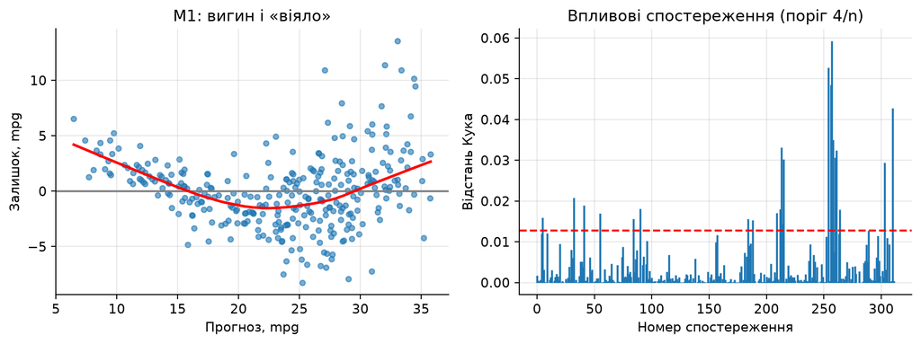

Figure 4: Залишки M1 проти прогнозів (LOWESS) і впливові спостереження

```python
cook = smf.ols(F1, T).fit().get_influence().cooks_distance[0]; cut = 4 / len(T)
fig, ax = plt.subplots(1, 2, figsize=(10, 3.8))
ax[0].scatter(m1.fittedvalues, m1.resid, s=16, alpha=.6); ax[0].axhline(0, color="grey")
ax[0].plot(*lowess(m1.resid, m1.fittedvalues, frac=.5).T, "r", lw=2)
ax[0].set(xlabel="Прогноз, mpg", ylabel="Залишок, mpg", title="M1: вигин і «віяло»")
ax[1].stem(np.arange(len(T)), cook, markerfmt=" ", basefmt=" "); ax[1].axhline(cut, color="r", ls="--")
ax[1].set(xlabel="Номер спостереження", ylabel="Відстань Кука", title="Впливові спостереження (поріг 4/n)")
save(fig, "diag_M1")
def thirds(m):
    f = m.fittedvalues
    return m.resid[f < f.quantile(1/3)].std(), m.resid[f > f.quantile(2/3)].std()
sd_lo, sd_hi = thirds(m1)
bp1 = het_breuschpagan(m1.resid, m1.model.exog)[1]
keep = cook <= cut
m1s = ols(F1, T[keep].copy())
top = T.assign(cook=cook, resid=m1.resid).nlargest(5, "cook")[["car_name", "model_year", "mpg", "resid", "cook"]]
```

**Код**

```python
md(top.rename(columns={"car_name": "Авто", "model_year": "Рік (19xx)", "resid": "Залишок", "cook": "Кук"}), 3)
```

Table 2: П’ять найвпливовіших спостережень M1

| Авто | Рік (19xx) | mpg | Залишок | Кук |
| --- | --- | --- | --- | --- |
| vw dasher (diesel) | 80 | 43,400 | 11,386 | 0,059 |
| mazda glc | 80 | 46,600 | 13,558 | 0,053 |
| vw rabbit c (diesel) | 80 | 44,300 | 10,936 | 0,049 |
| vw pickup | 82 | 44,000 | 9,470 | 0,043 |
| audi 5000s (diesel) | 80 | 36,400 | 7,944 | 0,035 |

- **Нелінійність.** LOWESS вигнутий: на краях діапазону прогнозів залишки здебільшого додатні, всередині від’ємні. M1 систематично занижує `mpg` на краях; один нахил маси усереднює різні нахили.
- **Неоднаковий розкид.** SD залишків зростає від 2,21 (нижня третина прогнозів) до 3,92 mpg (верхня); тест Бройша–Пагана: p < 0,001. Звичайні стандартні похибки ненадійні, тому використано стійкі; похибка прогнозу для економних авто більша за середню.
- **Впливові спостереження.** Поріг 4/n перевищують 22 точок. Це реальні авто, тому їх не вилучено. Без них коефіцієнт маси −1,25, року 0,69 mpg: знаки та висновки щодо H1–H2 не змінюються.

## 3.3 Спроби покращення

| Модифікація | Яку проблему має розв’язати |
| --- | --- |
| M2a: + (маса − 1300 кг)² | вигин залишків |
| M2b: M2a + маса × рік | різний темп змін для легких і важких |
| M2c: ln mpg ~ ln маси + ln потужності + рік + регіон | вигин **і** неоднаковий розкид; коефіцієнти маси й потужності — еластичності |
| M2d: ridge, додано об’єм, циліндри, розгін | мультиколінеарність розмірних ознак |
| M3 (додаткова): випадковий ліс, усі ознаки | довільна нелінійність і взаємодії |

Прогноз M2c переводимо в mpg через експоненту з поправкою Дуана, щоб оцінювати середнє `mpg`, а не медіану.

**Код**

```python
models = make_models()
res = cross_validate(train, models)
res.to_csv(TAB / "cv_folds.csv", index=False)
S = res.groupby("model", sort=False)[["RMSE", "MAE"]].agg(["mean", "std"])
P = res.pivot_table(index=["repeat", "fold"], columns="model", values="RMSE")[list(models)]
B, L = "M2c log-log", "M1 лінійна"
assert S[("RMSE", "mean")].idxmin() == B
R = S[("RMSE", "mean")]
tab = pd.DataFrame({"Модель": S.index,
  "RMSE": [f"{uk(a)} ± {uk(c)}" for a, c in S["RMSE"].values],
  "MAE": [f"{uk(a)} ± {uk(c)}" for a, c in S["MAE"].values],
  "Зміна RMSE до M1": [uk(100 * (a / R[L] - 1), 1) + " %" for a in R],
  "Краща за M1, розбиттів": [f"{int((P[n] < P[L]).sum())}/50" if n != L else "—" for n in S.index]})
tab.to_csv(TAB / "cv_summary.csv", index=False)
d31 = P["M3 випадковий ліс"] - P[B]
md(tab)
```

Table 3: Перехресна валідація на навчальній частині: середнє ± SD за 50 однаковими розбиттями, mpg

| Модель | RMSE | MAE | Зміна RMSE до M1 | Краща за M1, розбиттів |
| --- | --- | --- | --- | --- |
| M0 константа | 7,77 ± 0,64 | 6,52 ± 0,57 | 133,4 % | 0/50 |
| M1 лінійна | 3,33 ± 0,33 | 2,52 ± 0,22 | 0,0 % | — |
| M2a + маса² | 2,97 ± 0,28 | 2,18 ± 0,18 | −10,8 % | 49/50 |
| M2b + маса² + маса×рік | 2,88 ± 0,28 | 2,11 ± 0,18 | −13,4 % | 49/50 |
| M2c log-log | 2,79 ± 0,30 | 2,03 ± 0,20 | −16,2 % | 49/50 |
| M2d ridge, усі ознаки | 3,32 ± 0,32 | 2,54 ± 0,21 | −0,4 % | 33/50 |
| M3 випадковий ліс | 2,86 ± 0,35 | 2,03 ± 0,21 | −14,2 % | 47/50 |

**Код**

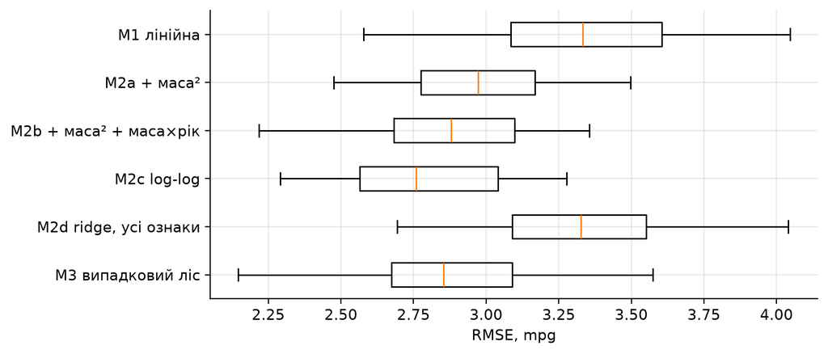

Figure 5: RMSE за 50 розбиттями (без константи)

```python
fig, ax = plt.subplots(figsize=(8, 3.5))
n = [m for m in P.columns if m != "M0 константа"]
ax.boxplot([P[m] for m in n], orientation="horizontal", tick_labels=n); ax.invert_yaxis()
ax.set(xlabel="RMSE, mpg"); save(fig, "cv_box")
```

Розбиття повторної CV перекриваються, тому SD описує розкид, але 50 значень не є незалежними.

**Що показала валідація.** Виправлення нелінійності допомагає: M2a і M2b кращі за M1. Найбільше дає M2c: RMSE 2,79 проти 3,33 mpg. Ridge практично не відрізняється від M1, бо проблема M1 — форма зв’язку, а не мультиколінеарність. Випадковий ліс не перевершив M2c (RMSE в середньому більший на 0,07 mpg; M2c краща у 29 із 50 розбиттів, тобто перевага невелика), а коефіцієнтів для інтерпретації не дає.

**Вибір зафіксовано: M2c** — мінімальний CV-RMSE; M1, M2a, M2b поступаються більш ніж на 1 %.

**Код**

```python
m2 = ols(F2)
c2 = coef(m2); c2.to_csv(TAB / "coef_M2c.csv", index=False)
g, h = m2.params, m2.conf_int()
bp2 = het_breuschpagan(m2.resid, m2.model.exog)[1]
sl, sh = thirds(m2)
pct = lambda x: 100 * (np.exp(x) - 1)
md(c2, 3)
```

Table 4: M2c: оцінки на навчальній частині (ціль — ln mpg)

| Член | Оцінка | 95 % ДІ, від | 95 % ДІ, до |
| --- | --- | --- | --- |
| Константа | 5,304 | 5,164 | 5,444 |
| Європа проти США | 0,064 | 0,021 | 0,107 |
| Японія проти США | 0,043 | 0,006 | 0,079 |
| ln маси | −0,724 | −0,825 | −0,622 |
| ln потужності | −0,161 | −0,251 | −0,070 |
| Рік, +1 | 0,031 | 0,027 | 0,035 |

Маса, більша на 1 %, пов’язана зі зміною `mpg` приблизно на −0,72 % (ДІ еластичності [−0,83; −0,62]); потужність, більша на 1 %, — на −0,16 % ([−0,25; −0,07]). Новіший на рік автомобіль економніший на 3,2 % ([2,8; 3,5]).

**Код**

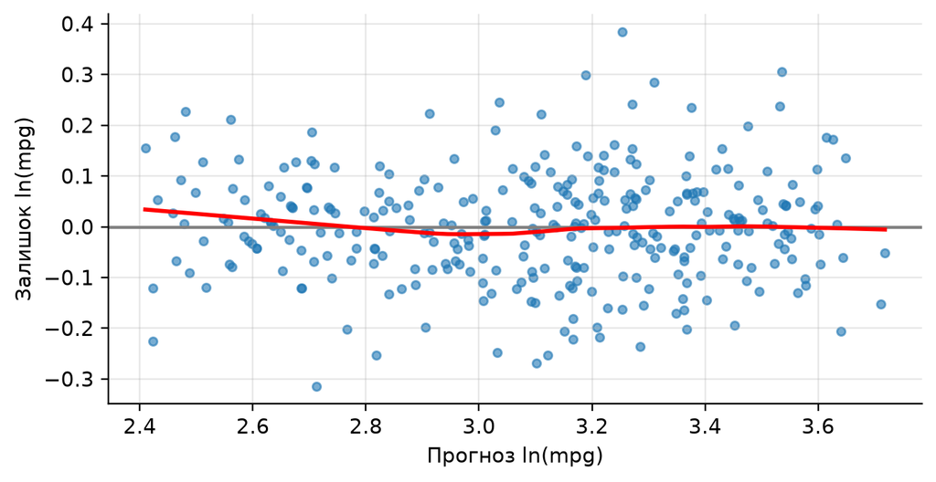

Figure 6: Залишки M2c (логарифмічна шкала) проти прогнозів

```python
fig, ax = plt.subplots(figsize=(6.5, 3.4))
ax.scatter(m2.fittedvalues, m2.resid, s=16, alpha=.6); ax.axhline(0, color="grey")
ax.plot(*lowess(m2.resid, m2.fittedvalues, frac=.5).T, "r", lw=2)
ax.set(xlabel="Прогноз ln(mpg)", ylabel="Залишок ln(mpg)"); save(fig, "diag_M2c")
```

SD залишків у нижній і верхній третинах прогнозів: 0,098 і 0,104 (відношення 1,06; у M1 було 1,78). Тест Бройша–Пагана: p = 0,066.

## 3.4 Фінальна оцінка на тесті

M2c перенавчено на всій навчальній частині й один раз оцінено разом із константою.

**Код**

```python
pred = {n: clone(models[n]).fit(train, train.mpg).predict(test) for n in ["M0 константа", B]}
rng = np.random.default_rng(SEED)
groups = list(test.groupby("model_id").indices.values())
boots = [np.concatenate([groups[i] for i in rng.integers(0, len(groups), len(groups))]) for _ in range(2000)]
rows, TM, BS = [], {}, {}
y = test.mpg.to_numpy()
for nme, p in pred.items():
    TM[nme] = M = metrics(y, p)
    BS[nme] = bs = pd.DataFrame([metrics(y[i], p[i]) for i in boots]).quantile([.025, .975])
    rows.append({"Модель": nme, "RMSE": M["RMSE"], "RMSE, 95 % ДІ": ci(*bs.RMSE), "MAE": M["MAE"], "MAE, 95 % ДІ": ci(*bs.MAE)})
tt = pd.DataFrame(rows); tt.to_csv(TAB / "test_metrics.csv", index=False)
gain = 100 * (1 - TM[B]["RMSE"] / TM["M0 константа"]["RMSE"])
md(tt)
```

Table 5: Тестова оцінка (mpg); 95 % ДІ — бутстреп за назвами моделей, 2000 повторів

| Модель | RMSE | RMSE, 95 % ДІ | MAE | MAE, 95 % ДІ |
| --- | --- | --- | --- | --- |
| M0 константа | 7,98 | [6,93; 9,00] | 6,69 | [5,72; 7,72] |
| M2c log-log | 3,07 | [2,38; 3,71] | 2,31 | [1,80; 2,89] |

**Код**

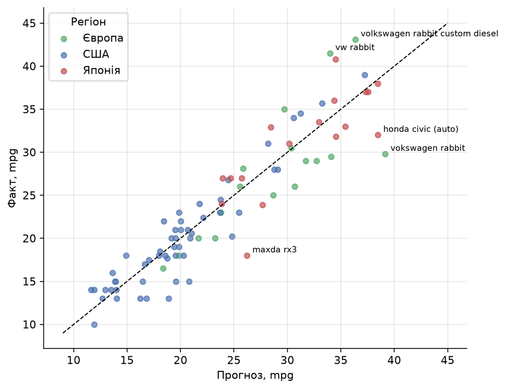

Figure 7: Тест: фактичні й прогнозовані значення M2c; підписано п’ять найбільших промахів

```python
E = test.assign(pred=pred[B]); E["err"] = E.mpg - E.pred; E["abs"] = E.err.abs()
fig, ax = plt.subplots(figsize=(6.8, 5.2))
for o, q in E.groupby("origin"): ax.scatter(q.pred, q.mpg, s=26, alpha=.7, color=COL[o], label=o)
ax.plot([9, 45], [9, 45], "k--", lw=1)
for _, r in E.nlargest(5, "abs").iterrows():
    ax.annotate(r.car_name, (r.pred, r.mpg), fontsize=8, xytext=(5, 3), textcoords="offset points")
ax.set(xlabel="Прогноз, mpg", ylabel="Факт, mpg"); ax.legend(title="Регіон"); save(fig, "test_pred")
```

**Код**

```python
def eg(key, name):
    a = E.groupby(key, observed=True).err.agg(n="size", bias="mean", RMSE=lambda e: np.sqrt((e**2).mean()), MAE=lambda e: e.abs().mean()).reset_index()
    a.columns = ["Група", "n", "Середня похибка", "RMSE", "MAE"]
    a["Група"] = name + ": " + a["Група"].astype(str); return a
eb = pd.concat([eg(pd.cut(E.pred, [0, 18, 26, 60], labels=["<18 mpg", "18–26 mpg", ">26 mpg"]), "прогноз"), eg("origin", "регіон")])
eb.to_csv(TAB / "test_errors.csv", index=False)
md(eb)
```

Table 6: Похибки на тесті за діапазоном прогнозу й регіоном (похибка = факт − прогноз)

| Група | n | Середня похибка | RMSE | MAE |
| --- | --- | --- | --- | --- |
| прогноз: <18 mpg | 18 | 0,18 | 1,85 | 1,46 |
| прогноз: 18–26 mpg | 38 | −0,35 | 2,37 | 1,84 |
| прогноз: >26 mpg | 30 | −0,29 | 4,23 | 3,42 |
| регіон: Європа | 17 | −0,93 | 4,35 | 3,56 |
| регіон: США | 52 | 0,03 | 2,29 | 1,78 |
| регіон: Японія | 17 | −0,26 | 3,57 | 2,68 |

**Код**

```python
tp = E.nlargest(5, "abs")[["car_name", "model_year", "origin", "mpg", "pred", "err"]]
tp.to_csv(TAB / "test_top_errors.csv", index=False)
md(tp.rename(columns={"car_name": "Авто", "model_year": "Рік (19xx)", "origin": "Регіон", "pred": "Прогноз", "err": "Похибка"}))
```

Table 7: П’ять найбільших похибок на тесті

| Авто | Рік (19xx) | Регіон | mpg | Прогноз | Похибка |
| --- | --- | --- | --- | --- | --- |
| vokswagen rabbit | 80 | Європа | 29,80 | 39,16 | −9,36 |
| maxda rx3 | 73 | Японія | 18,00 | 26,23 | −8,23 |
| vw rabbit | 80 | Європа | 41,50 | 33,99 | 7,51 |
| volkswagen rabbit custom diesel | 78 | Європа | 43,10 | 36,37 | 6,73 |
| honda civic (auto) | 82 | Японія | 32,00 | 38,48 | −6,48 |

**Аналіз помилок.** Найбільші похибки — в економних авто (прогноз понад 26 mpg): їх RMSE більш ніж удвічі вищий, ніж у групі до 18 mpg. Серед п’яти найбільших промахів — дизельний VW Rabbit (тип пального не є предиктором) і Mazda RX-3 з роторним двигуном, які модель не відрізняє від звичайних бензинових авто. Два *vw rabbit* 1980 р. мають дуже різні `mpg` (29,8 і 41,5), а помилки моделі для них протилежні за знаком: наявні ознаки цієї різниці не пояснюють. Європейських та японських авто в тесті лише по 17, тому їхні RMSE неточні.

Тестовий RMSE дещо вищий за CV (3,07 проти 2,79), але CV-оцінка лежить у межах ДІ тесту.

# 4 Обговорення й висновки

**Відповідь на питання.** За масою, потужністю, роком і регіоном `mpg` нової моделі того самого ринку прогнозується з RMSE 3,07 mpg (95 % ДІ [2,38; 3,71]) і MAE 2,31 mpg. Це на 62 % менший RMSE, ніж у константи.

**H1 узгоджується з даними (розвідувально).** У M1 +100 кг пов’язані з −1,19 mpg (95 % ДІ [−1,38; −1,01]), ДІ цілком нижчий за 0. Проте форма зв’язку нелінійна: M2c дає еластичність −0,72 ([−0,83; −0,62]), тому «−1,2 mpg на 100 кг» — лише усереднення, для легких авто різниця більша. Знак узгоджується з Reynolds і Kandlikar.

**H2 узгоджується з даними (розвідувально).** У M1 +1 рік пов’язаний з 0,73 mpg ([0,61; 0,84]); у M2c це 3,2 % на рік. Напрям узгоджується з прогресом за Knittel та описом EPA. Рік об’єднує технології, регулювання й ринкові зміни після нафтових криз, тому це не «чистий ефект технологій».

**Потужність.** У M1 її внесок невизначений (ДІ містить 0), а в логарифмічній формі еластичність −0,16 ([−0,25; −0,07]) відмінна від нуля: висновок про окремий предиктор залежить від специфікації, а маса й потужність корельовані.

**Якість прогнозу на нових даних.** M2c корисна для групових оцінок, але для окремого економного авто типова похибка (RMSE) становить близько 4 mpg. Перевага над випадковим лісом мала; головний виграш дала правильна форма зв’язку.

**Межі узагальнення.** Лише ринок США 1970–1982; не стосується гібридів, електромобілів і пізніших років. Тест містить 86 авто і не є цілком незалежним від EDA лабораторної №2. Марка та платформа можуть пов’язувати різні назви моделей навіть після поділу за назвою. Частину описок у самих назвах моделей могло бути не виправлено.

**Змішувальні чинники.** Тип пального, трансмісія, аеродинаміка, клас авто та регуляторні вимоги пов’язані і з масою чи роком, і з `mpg`. Дослідження спостережне, тому всі коефіцієнти — умовні асоціації.

**Продовження.** Розмітити тип пального й трансмісію для наявних авто, додати ці ознаки до M2c, навчити її на 1970–1982 рр. і перевірити на зібраних окремо авто 1983–1985 рр. Це буде перевірка на справді нових даних із часовим поділом.

# Відтворюваність

**Код**

```python
vers = {"python": platform.python_version(), **{m.__name__: m.__version__ for m in (np, pd, scipy, sklearn, statsmodels, matplotlib)}}
json.dump({"seed": SEED, "n_train": len(train), "n_test": len(test), "gain_pct": gain, "cv_rmse": R.to_dict(), "versions": vers},
          open("outputs/summary.json", "w", encoding="utf8"), ensure_ascii=False, indent=2)
Markdown(", ".join(f"{a} {v}" for a, v in vers.items()))
```

python 3.12.10, numpy 2.5.5, pandas 3.1.1, scipy 1.18.1, sklearn 1.9.1, statsmodels 0.15.0, matplotlib 3.11.2

# Бібліографія

Knittel, Christopher R. 2011. «Automobiles on Steroids: Product Attribute Trade-Offs and Technological Progress in the Automobile Sector». *American Economic Review* 101 (7): 3368–99. https://doi.org/10.1257/aer.101.7.3368.

Quinlan, J. Ross. 1993. «Combining Instance-Based and Model-Based Learning». *Machine Learning Proceedings 1993*, 236–43. https://doi.org/10.1016/b978-1-55860-307-3.50037-x.

Quinlan, R. 1993. *Auto MPG [Dataset]*. UCI Machine Learning Repository. https://archive.ics.uci.edu/dataset/9/auto+mpg.

Reynolds, Conor C. O., і Milind Kandlikar. 2007. «How hybrid-electric vehicles are different from conventional vehicles: the effect of weight and power on fuel consumption». *Environmental Research Letters* 2 (1): 014003. https://doi.org/10.1088/1748-9326/2/1/014003.

U.S. Environmental Protection Agency. 2026. *Highlights of the Automotive Trends Report*. https://www.epa.gov/automotive-trends/highlights-automotive-trends-report.